# GLM (Poisson Regression) Example

Lecture 10

February 13, 2026

# Review

## GLMs

- Use linear model to specify (usually transformed) parameters of a non-Gaussian distribution.
- Can be more challenging to specify, interpret, and check.
- **Examples**: Poisson, Binomial regression, but almost unlimited combinations of distribution + link possible.

## Poisson Regression Example

- The data is **overdispersed** relative to a Poisson distribution.
- But a Poisson GLM may produce overdispersed data, since every observation has a different $\lambda_i$ (hence mean and variance.)

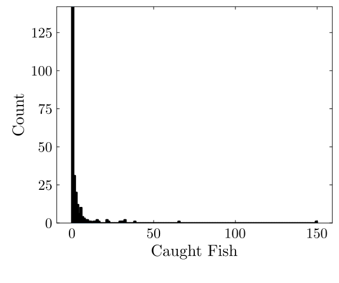

Figure 1: Fishing Data

## Be Cautious…

- Over-relying on plots like histograms can lead to mis-specifying GLM dynamics.
- Think of linear regression: the question is **not if the data are Gaussian but the residuals**.

[figure not shown]

Brain on Regression Meme

Source: Richard McElreath

## Model Specification

We might hypothesize that the number of fish caught is influenced by the number of children (noisy, distracting, impatient) and whether the party brought a camper.

$$\begin{align*}
y_i &\sim \text{Poisson}(\lambda_i) \\
f(\lambda_i) &= \beta_0 + \beta_1 \text{child}_i + \beta_2 \text{camper}_i
\end{align*}$$

$\lambda_i$: positive “rate”

$f(\cdot)$: maps positive reals (rate scale) to all reals (linear model scale)

## Fitting the Model

```julia
function fish_model(params, child, camper, fish_caught)
    β₀, β₁, β₂ = params
    λ = exp.(β₀ .+ β₁ * child + β₂ * camper)
    loglik = sum(logpdf.(Poisson.(λ), fish_caught))
end

lb = [-100.0, -100.0, -100.0]
ub = [100.0, 100.0, 100.0]
init = [0.0, 0.0, 0.0]

optim_out = optimize(θ -> -fish_model(θ, fish.child, fish.camper, fish.fish_caught), lb, ub, init)
θ_mle = optim_out.minimizer
@show round.(θ_mle; digits=2);
@show round.(exp.(θ_mle); digits=2);
```

```
round.(θ_mle; digits = 2) = [0.91, -1.23, 1.05]
round.(exp.(θ_mle); digits = 2) = [2.48, 0.29, 2.87]
```

## Interpretation of Coefficients

Since $\log(\lambda_i) = \sum_j \beta_j x^i_j$:

$\exp(\beta_j)$ says how much a unit increase in $x_j$ multiplies the rate (hence expected value).

So $\beta_1 =$ -1.2 says that each extra child reduces the expected number of fish caught by a factor of 0.3.

## Predictive Checks To Evaluate Model

- Linear regression: model checking was straightforward: residuals should have been Gaussian distributed.
- GLMs: Less clear how to check distributional assumptions.

**Strategy**: check predictive distribution of relevant summary statistic(s) by simulation; do you capture the empirical statistic?

## Predictive Checks

In other words, for some statistic $T$:

- Estimate $\hat{T}$ from the data.
- Simulate synthetic datasets using your model and calculate $\tilde{T}_n$ for each one;
- Examine the distribution of $(\tilde{T})$ to see where $\hat{T}$ falls.

**Teaser**: This is closely related to the idea of a $p$-value…

## Checking Proportion of Zero Fish

```julia
# simulate samples for each P
λ = exp.(θ_mle[1] .+ θ_mle[2] * fish.child .+ θ_mle[3] * fish.camper)
# draw 10,000 samples for each
fish_sim = zeros(10_000, nrow(fish)) # initialize matrix to store simulations
for i = 1:nrow(fish)
    fish_sim[:, i] = rand(Poisson(λ[i]), 10_000)
end

# calculate frequency of zeros
fish_zeros = mapslices(row -> sum(row .== 0) / length(row), fish_sim; dims=1)
histogram(fish_zeros', xlabel="Proportion of Zeros", ylabel="Count", label=false)
vline!([sum(fish.fish_caught .== 0) / nrow(fish)], color=:red, linewidth=3, label="Empirical Statistic")
```

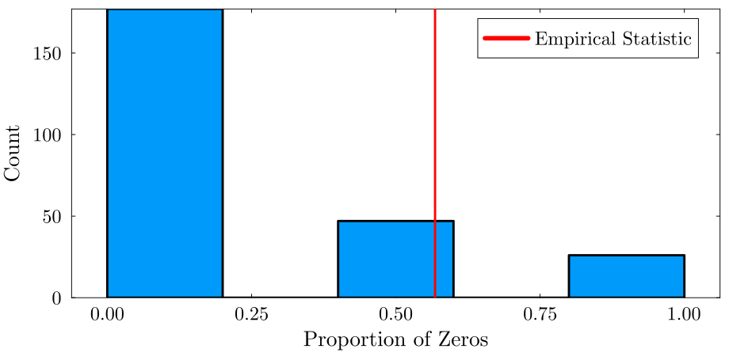

Figure 2: Predictive distribution for fitted fish model.

## What Was The Problem?

- The model produces far fewer zero-fish counts than the data.
- This is typical of a lot of environmental count data; often have far more zeros than would be expected from a Poisson regression.
- Alternative: Use a **zero-inflated model**.

# Zero-Inflated Models

## Mixture Models

When we have two different data-generating processes which produce the same observable outcome, may need to use a **mixture** of two distributions to capture outcome.

**Distribution 1**: $\mathcal{D}_1$ with likelihood $L_1(\theta_1 | y)$.

**Distribution 2**: $\mathcal{D}_2$ with likelihood $L_1(\theta_2 | y)$.

## Mixture Model Likelihood

Then if $y_i \sim \mathcal{D}_1$ with probability $p_i$, $y_i \sim \mathcal{D}_2$ with probability $p_{i-1}$.

$$L(p_i, \theta_1, \theta_2) = \prod_{i=1}^n \left(p_1 L_1(\theta_1 | y_i) + p_2 L_2(\theta_2 | y_i)\right)$$

## Fitting Mixture Models

This can get complicted (and require more complicated algorithms) when with many or similar mixture components. But our case is easier!

## Example: Mixture Rationale

- Some groups don’t fish, which guarantees no fish.
- Probability of fishing is influenced by size of group.
- If a group fishes, then there’s a Poisson process for the number of fish they catch.
- Expected fishing influenced by children and campers.

## Zero-Inflated Poisson

This is a **mixture** between a Poisson and point-distribution (Dirac distribution) at zero.

$$\begin{aligned}
y_i &\sim p_i \text{Dirac}(0) + (1 - p_i) \text{Poisson}(\lambda_i) \\
\text{logit}(p_i) &= \alpha_0 + \alpha_1 \text{persons}_i\\
\log(\lambda_i) &= \beta_0 + \beta_1 \text{child}_i + \beta_2 \text{camper}_i
\end{aligned}$$

## ZIP Likelihood

If $y = 0$:

$$\mathcal{L}(p_i, \lambda_i | y_i = 0) = p_i + (1 - p_i) \overbrace{e^{-\lambda_i}}^{\text{Poisson zero likelihood}}$$

If $y > 0$:

$$\mathcal{L}(p_i, \lambda_i | y_i > 0) = (1 - p_i) \underbrace{\frac{\lambda_i^{y_i}e^{-\lambda_i}}{y_i!}}_{\text{Poisson likelihood}}$$

## Fitting ZIP

```julia
invlogit(x) = exp(x) / (1 + exp(x))
ZeroInflated(p, λ) = MixtureModel([Dirac(0), Poisson(λ)], [p, 1 - p])
function fish_model_zip(params, persons, child, camper, fish_caught)
    α₀, α₁, β₀, β₁, β₂ = params
    p = invlogit.(α₀ .+ α₁ * persons)
    λ = exp.(β₀ .+ β₁ * child .+ β₂ * camper)
    ll = sum(logpdf.(ZeroInflated.(p, λ), fish_caught))
    return ll
end

lb = [-100.0, -100.0, -100.0, -100.0, -100.0]
ub = [100.0, 0.0, 100.0, 100.0, 100.0]
init = [5.0, -2.0, 0.0, 0.0, 0.0]

optim_out = optimize(θ -> -fish_model_zip(θ, fish.persons, fish.child, fish.camper, fish.fish_caught), lb, ub, init)
θ_mle = optim_out.minimizer
@show round.(θ_mle; digits=2);
@show round.(exp.(θ_mle); digits=2);
```

```
round.(θ_mle; digits = 2) = [1.3, -0.56, 1.6, -1.04, 0.83]
round.(exp.(θ_mle); digits = 2) = [3.66, 0.57, 4.94, 0.35, 2.3]
```

## Evaluating Model Fit

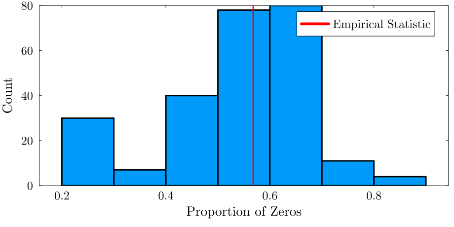

Figure 3: Predictive distribution for fitted fish model.

```julia
# simulate samples for each P
p = invlogit.(θ_mle[1] .+ θ_mle[2] * fish.persons)
λ = exp.(θ_mle[3] .+ θ_mle[4] * fish.child .+ θ_mle[5] * fish.camper)
# draw 10,000 samples for each
fish_sim = zeros(10_000, nrow(fish)) # initialize matrix to store simulations
for i = 1:nrow(fish)
    u = rand(Uniform(0, 1), 10_000)
    for j = 1:10_000
       if u[j] < p[i]
            fish_sim[j, i] = 0.0
        else
            fish_sim[j, i] = rand(Poisson(λ[i]))
        end
    end
end

# calculate frequency of zeros
fish_zeros = mapslices(row -> sum(row .== 0) / length(row), fish_sim; dims=1)
histogram(fish_zeros', xlabel="Proportion of Zeros", ylabel="Count", label=false)
vline!([sum(fish.fish_caught .== 0) / nrow(fish)], color=:red, linewidth=3, label="Empirical Statistic")
```

## Interpretation of Check

- This is much better, but is only one test.
- A model has more evidence for it if it passes multiple checks.
- But none of this can “prove” a model is right: need to rely on hypotheses and EDA to propose a sensible model.

# Key Points and Upcoming Schedule

## Key Points

- Zero-inflation can address problems where data have more zeros than GLM distribution would suggest.
- Simple version of a mixture model.

## Upcoming Schedule

**Monday**: No class, enjoy break.

**Next Two Weeks**: Extreme Values

**HW2**: Due 2/20

**Project Proposal**: Due 2/27